# Data Visualization - C&A, IIT Guwahati

## 2. Heatmaps

Sometimes Heatmaps are a good alternative to Clustered Bar Graphs (specially, where clustered bar charts can become clumsy in case of lots of categorical variables)

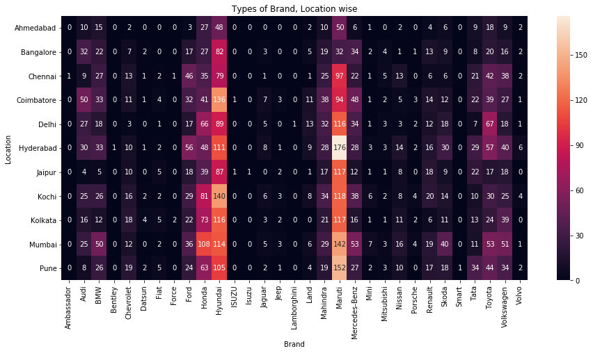

```python
plt.figure(figsize=[15, 7])
sns.heatmap(pd.crosstab(data.Location, data.Brand), annot=True, fmt="d");
sns.color_palette("BuGn_r")
plt.title('Types of Brand, Location wise');
```

## For heatmap above:

- annot means, whether to print actual value counts
- fmt ="d" means print values in integer form
- Colro palette taken from [here](https://seaborn.pydata.org/tutorial/color_palettes.html)
- More about Heatmap parameters can be found [here](https://seaborn.pydata.org/generated/seaborn.heatmap.html)

## 3. Faceting

- Faceting can almost work for any multivariate plot if there is a categorical variable involved.
- Bascially it creates seperate subplots for each category and then individual univarate plots in each one of them.

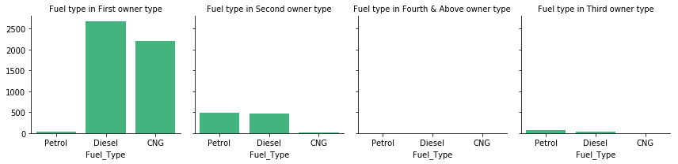

```python
g = sns.FacetGrid(data=data, col='Owner_Type')
g.map(sns.countplot, 'Fuel_Type', color=green3)
g.set_titles('Fuel type in {col_name} owner type');
```

## Extra: 3-variate plot using Faceting

- Faceted by Transmission type
- In each FacetGrid, a Categorical (Fuel Type) vs Numerical (Price) barplot

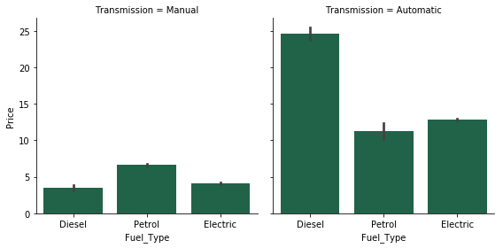

```python
g = sns.FacetGrid(data=data, col='Transmission', size=4)
g.map(sns.barplot,'Fuel_Type','Price', color=green1);
```

**Bascially, you can do multi-variate explorations easily by Faceting More will be taught ahead!**

# Bivariate Explorations

### Case 3: Categorical vs Numerical

Navigate Down

## Many Options

- Boxplot
- Violin Plot
- Barplot
- Faceting

## 1. Box Plot

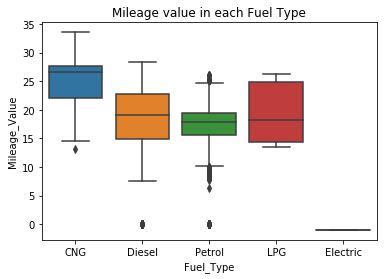

```python
sns.boxplot(data=data, x='Fuel_Type', y='Mileage_Value')
plt.title('Mileage value in each Fuel Type');
```

**Many problems in the above plot. Hopefully, you would've figured out Check next subslide**

## Good Practice for Box Plots

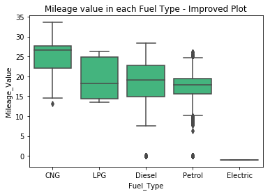

```python
ordering = data.groupby('Fuel_Type')['Mileage_Value'].mean().sort_values(ascending=False).index
sns.boxplot(data=data, x='Fuel_Type', y='Mileage_Value', color=green3,
           order = ordering)
plt.title('Mileage value in each Fuel Type - Improved Plot');
```

## Shifting Axes possible

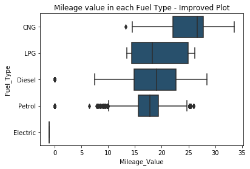

```python
ordering = data.groupby('Fuel_Type')['Mileage_Value'].mean().sort_values(ascending=False).index
sns.boxplot(data=data, y='Fuel_Type', x='Mileage_Value', color=blue1,
           order = ordering)
plt.title('Mileage value in each Fuel Type - Improved Plot');
```

## 2. Violin Plot

Exactly same syntax as Box Plots. Just replace "boxplot" by "violinplot"

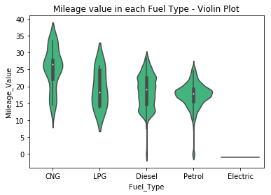

```python
ordering = data.groupby('Fuel_Type')['Mileage_Value'].mean().sort_values(ascending=False).index
sns.violinplot(data=data, x='Fuel_Type', y='Mileage_Value', color=green3,
           order = ordering)
plt.title('Mileage value in each Fuel Type - Violin Plot');
```

## 3. Bar Plot

Same syntax as boxplot. Just replace "boxplot" by "barplot"

[figure not shown]

```python
ordering = data.groupby('Fuel_Type')['Mileage_Value'].mean().sort_values(ascending=False).index
sns.barplot(data=data, x='Fuel_Type', y='Mileage_Value', color=green3,
           order = ordering)
plt.title('Mileage value in each Fuel Type - Violin Plot');
```

**Important Question: What is the difference between Bar Plot and Box/Violin Plot?**

## Another Example

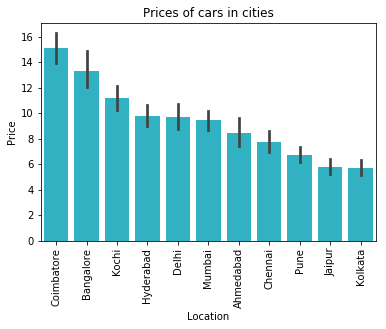

```python
sns.barplot(data=data, x='Location', y='Price', color=blue3,
           order = data.groupby('Location')['Price'].mean().sort_values(ascending=False).index)
plt.title('Prices of cars in cities');
plt.xticks(rotation=90);
```

## 4. Faceting

Here we deal with this again. As we have one Categorical feature - Faceting is possible.

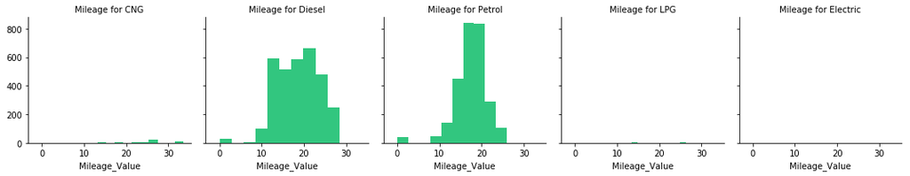

```python
g = sns.FacetGrid(data=data, col="Fuel_Type")
g.map(plt.hist, 'Mileage_Value', color=green3)
g.set_titles('Mileage for {col_name}');
```

## Hurray! You completed Bivariate Explorations

#### You roll!

[figure not shown]

# Bivariate Explorations

## Summary

- **Case 1: Numerical vs Numerical**: Scatterplots
- **Case 2: Categorical vs Categorical**: Clustered Bar Graphs, Heatmaps and Faceting
- **Case 3: Categorical vs Numerical**: Box/Violin Plots, Barplots and Faceting

# Multivariate Explorations

Coming Soon

# The End

Woahh! You've reached till the end of the self-paced tutorial. We hope this must've added some value to your Data Visualization skillset. We are a student-body at IIT Guwahati (India), named as [Consulting & Analytics Club, IIT Guwahati](https://www.linkedin.com/company/caciitg). We do cool stuff related to Data Science and Management Consulting. Do follow us on following mediums to stay updated :)

[Facebook](https://www.facebook.com/caciitg) $\;\;\;\;\;\;$ [Linkedin](https://www.linkedin.com/company/caciitg) $\;\;\;\;\;\;$ [Medium](https://medium.com/@caciitg)